# Programming with Python - CIA2

## Submitted by Ajay Tom(2227002)

# 1. INTRODUCTION

### Why is CRM required for MSMEs?

The MSME sector is a critical part of any economy, and it comprises a large number of businesses that operate in various industries. These businesses face many challenges, including intense competition, limited resources, and a constantly evolving market.

To stay competitive and grow their businesses, MSMEs need to build strong relationships with their customers. They need to understand their customers' needs, preferences, and behaviours and provide them with personalized and timely services. However, many MSMEs struggle to manage customer data effectively and efficiently, which can lead to lost opportunities, decreased customer satisfaction, and decreased revenue.

A CRM system can help MSMEs address these challenges by providing them with a centralized platform to manage customer data. By storing customer data in a structured and organized manner, MSMEs can gain insights into their customers' behaviours, preferences, and needs, which can help them tailor their services and improve customer satisfaction. A CRM system can also automate many of the routine tasks involved in customer management, such as lead tracking, sales forecasting, and customer support, which can save MSMEs time and resources.

CRM system can help MSMEs build stronger and more profitable relationships with their customers, which is essential for their long-term success.

### Problem Statement:

Micro and small business owners struggle with managing customer data, resulting in missed revenue opportunities. There is a need for a low-cost and user-friendly CRM solution that can help MSMEs effectively manage their customer relationships, automate tasks, and boost revenue generation.

# 2. E-R Diagram

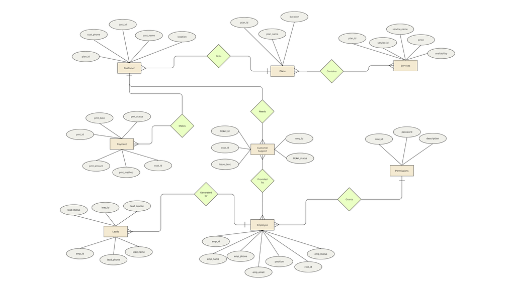

# 3. Process Flow Diagram

[figure not shown]

# 4. Coding - Tables(Files)

## 4.1.CUSTOMER

```python
table_cust = open('C:\\Users\\imaja\\OneDrive\\Desktop\\MBA 2022 -2024\\T3\\Python\\CIA2\\customer.csv','w')
```

```python
def add_cust():
    cust_id = input("Enter the customer ID: ")
    cust_name = input("Enter the customer name: ")
    cust_phone = int(input("Enter the phone number: "))
    location = input("Enter the location: ")

    display_plans()
    plan_id = input("Enter the Plan ID: ")

    table_cust = open('C:\\Users\\imaja\\OneDrive\\Desktop\\MBA 2022 -2024\\T3\\Python\\CIA2\\customer.csv','a')
    table_cust.write(f"{cust_id},{cust_name},{cust_phone},{location},{plan_id}\n")

    print("Customer Added Successfully")
    table_cust.close()
```

```python
add_cust()
```

```
Enter the Customer ID: C003
Enter the Customer name: Rahul
Enter the Phone number: 9394391723
Enter the Location: Bangalore
P01,Basic,3
P02,Medium,6
P03,Advanced,12

Enter the Plan ID: P02
Customer Added Successfully
```

```python
def display_cust():
    print("CUSTOMERS\n----------------")
    table_cust = open('C:\\Users\\imaja\\OneDrive\\Desktop\\MBA 2022 -2024\\T3\\Python\\CIA2\\customer.csv','r')
    print(table_cust.read())
    table_cust.close()
```

```python
display_cust()
```

```
C0002,Ann,9346155616,Kottayam,P02
C0003,Rahul,9394391723,Bangalore,P03
```

```python
def update_cust():
    cust_id = input("Enter the Customer ID to update: ")
    found = False

    with open('C:\\Users\\imaja\\OneDrive\\Desktop\\MBA 2022 -2024\\T3\\Python\\CIA2\\customer.csv', 'r+') as table_cust:
        lines = table_cust.readlines()
        table_cust.seek(0)
        for i, line in enumerate(lines):
            if line.startswith(cust_id + ','):
                found = True
                existing_cust = line.strip().split(',')

                cust_id = input(f"Enter the new ID for {existing_cust[0]}: ")
                cust_name = input(f"Enter the new name for {existing_cust[1]}: ")
                cust_phone = input(f"Enter the new phone number for {existing_cust[2]}: ")
                location = input(f"Enter the new location for {existing_cust[3]}: ")

                display_plans()
                plan_id = input(f"Enter the new plan ID for {existing_cust[4]}: ")

                new_line = f"{cust_id},{cust_name},{cust_phone},{location},{plan_id}\n"
                lines[i] = new_line
                break

        if not found:
            print("Customer not found!")
            return

        table_cust.writelines(lines)
        table_cust.truncate()

    print("Customer details updated successfully!")
```

```python
update_cust()
```

```
Enter the Customer ID to update: C0003
Enter the new ID for C0003: C0003
Enter the new name for Rahul: Rahul
Enter the new phone number for 9394391723: 9394391723
Enter the new location for Bangalore: Bangalore
P01,Basic,3
P02,Medium,6
P03,Advanced,12

Enter the new plan ID for P02: P03
Customer details updated successfully!
```

```python
def delete_cust():
    cust_id = input("Enter the Customer ID to delete: ")
    found = False

    with open('C:\\Users\\imaja\\OneDrive\\Desktop\\MBA 2022 -2024\\T3\\Python\\CIA2\\customer.csv', 'r+') as table_cust:
        lines = table_cust.readlines()
        table_cust.seek(0)
        for line in lines:
            if not line.startswith(cust_id + ','):
                table_cust.write(line)
            else:
                found = True
        table_cust.truncate()

    if found:
        print("Customer deleted successfully!")
    else:
        print("Customer not found!")
```

```python
delete_cust()
```

```
Enter the Customer ID to delete: C0001
Customer deleted successfully!
```

```python
def view_profile(cust_id):
    print("Your Account😎\n----------------")
    found = False

    with open('C:\\Users\\imaja\\OneDrive\\Desktop\\MBA 2022 -2024\\T3\\Python\\CIA2\\customer.csv', 'r') as table_cust:
        for line in table_cust:
            if line.startswith(cust_id + ','):
                cust_details = line.strip().split(',')
                print(f"ID: {cust_details[0]}")
                print(f"Name: {cust_details[1]}")
                print(f"Phone: {cust_details[2]}")
                print(f"Location: {cust_details[3]}")
                print(f"Plan ID: {cust_details[4]}")
                found = True
                break

    if not found:
        print("Customer not found!")
```

```python
view_profile()
```

```
Enter the customer ID: C0002
ID: C0002
Name: Ann
Phone: 9346155616
Location: Kottayam
Plan ID: P02
```

## 4.2.SERVICE

```python
table_services = open('C:\\Users\\imaja\\OneDrive\\Desktop\\MBA 2022 -2024\\T3\\Python\\CIA2\\services.csv','w')
```

```python
def add_service():
    service_id = input("Enter the Service ID: ")
    service_name = input("Enter the Service name: ")
    price = int(input("Enter the Price: "))
    availability = input("Enter the Avalability(LIVE/CLOSED): ")
    display_plans()
    plan_id = input("Enter the Plan ID: ")

    table_services = open('C:\\Users\\imaja\\OneDrive\\Desktop\\MBA 2022 -2024\\T3\\Python\\CIA2\\services.csv','a')
    table_services.write(f"{service_id},{service_name},{price},{availability},{plan_id}\n")

    print("Service Added Successfully")
    table_services.close()
```

```python
add_service()
```

```
Enter the Service ID: S01
Enter the Service name: Delivery
Enter the Price: 50
Enter the Avalability(LIVE/CLOSED): LIVE
Enter the Plan ID: P03
Service Added Successfully
```

```python
def display_services():

    print("Services we offer😮\n---------------------")
    table_services = open('C:\\Users\\imaja\\OneDrive\\Desktop\\MBA 2022 -2024\\T3\\Python\\CIA2\\services.csv','r')
    print(table_services.read())
    table_services.close()
```

```python
display_services()
```

```
S01,Delivery,50,LIVE,P03
```

## 4.3.Plans

```python
table_plans = open('C:\\Users\\imaja\\OneDrive\\Desktop\\MBA 2022 -2024\\T3\\Python\\CIA2\\plans.csv','w')
```

```python
plan_id = input("Enter the plan ID: ")
plan_name = input("Enter the plan name: ")
duration = int(input("Enter the duration: "))

table_plans = open('C:\\Users\\imaja\\OneDrive\\Desktop\\MBA 2022 -2024\\T3\\Python\\CIA2\\plans.csv','w')
table_plans.write(f"{plan_id},{plan_name},{duration}\n")

print("Plans Added Successfully")
table_plans.close()
```

```
Enter the plan ID: P01
Enter the plan name: Basic
Enter the duration: 3
Plans Added Successfully
```

```python
plan_id = input("Enter the plan ID: ")
plan_name = input("Enter the plan name: ")
duration = int(input("Enter the duration: "))

table_plans = open('C:\\Users\\imaja\\OneDrive\\Desktop\\MBA 2022 -2024\\T3\\Python\\CIA2\\plans.csv','a')
table_plans.write(f"{plan_id},{plan_name},{duration}\n")

print("Plans Added Successfully")
table_plans.close()
```

```
Enter the plan ID: P03
Enter the plan name: Advanced
Enter the duration: 12
Plans Added Successfully
```

```python
def display_plans():
    print("Choose the best plan for you😍\n-----------------------")
    table_plans = open('C:\\Users\\imaja\\OneDrive\\Desktop\\MBA 2022 -2024\\T3\\Python\\CIA2\\plans.csv','r')
    print(table_plans.read())
    table_plans.close()
```

```python
display_plans()
```

```
P01,Basic,3
P02,Medium,6
P03,Advanced,12
```

## 4.4.Permissions

```python
table_permissions = open('C:\\Users\\imaja\\OneDrive\\Desktop\\MBA 2022 -2024\\T3\\Python\\CIA2\\permissions.csv','w')
```

```python
role_id = input("Enter the Role ID: ")
password = int(input("Enter the password: "))
description = input("Enter the description: ")

table_permissions = open('C:\\Users\\imaja\\OneDrive\\Desktop\\MBA 2022 -2024\\T3\\Python\\CIA2\\permissions.csv','a')
table_permissions.write(f"{role_id},{password},{description}\n")

print("Plans Added Successfully")
table_permissions.close()
```

```
Enter the Role ID: R04
Enter the password: 516
Enter the description: Customer Support: Can access and manage customer support tickets and interactions.
Plans Added Successfully
```

```python
def display_permissions():
    print("PERMISSIONS\n----------------")
    table_permissions = open('C:\\Users\\imaja\\OneDrive\\Desktop\\MBA 2022 -2024\\T3\\Python\\CIA2\\permissions.csv','r')
    print(table_permissions.read())
    table_permissions.close()
```

```python
display_permissions()
```

```
R01,123,Admin: Has full access to all features and settings in the CRM system.
R02,223,Manager: Can access and manage data for their team or department, but does not have access to all settings.
R03,333,Sales Rep: Can view and manage their own leads, contacts, and opportunities.
R04,516,Customer Support: Can access and manage customer support tickets and interactions.
```

## 4.5.Payment

```python
table_pmt = open('C:\\Users\\imaja\\OneDrive\\Desktop\\MBA 2022 -2024\\T3\\Python\\CIA2\\payment.csv','w')
```

```python
def add_payment(cust_id):
    import random

    pmt_id = random.randint(222222,999999)
    pmt_date = input("Enter the payment date(DD/MM/YYY): ")
    pmt_amount = int(input("Enter the payment amount: "))
    pmt_method = input("Enter the payment method: ")
    pmt_status = "SUCCESS"


    table_pmt = open('C:\\Users\\imaja\\OneDrive\\Desktop\\MBA 2022 -2024\\T3\\Python\\CIA2\\payment.csv','a')
    table_pmt.write(f"{cust_id},{pmt_id},{pmt_date},{pmt_amount},{pmt_method},{pmt_status}\n")

    print("Payment Successful")
    table_pmt.close()
```

```python
add_payment()
```

```
Enter the customer ID: C0001
Enter the payment date(DD/MM/YYY): 17/11/2021
Enter the payment amount: 450
Enter the payment method: UPI
Payment Successful
```

```python
def display_payment():
    print("PAYMENT\n----------------")
    table_pmt = open('C:\\Users\\imaja\\OneDrive\\Desktop\\MBA 2022 -2024\\T3\\Python\\CIA2\\payment.csv','r')
    print(table_pmt.read())
    table_pmt.close()
```

```python
display_payment()
```

```
C0001,855784,17/11/2021,450,UPI,SUCCESS
```

## 4.6. Customer Support

```python
table_support = open('C:\\Users\\imaja\\OneDrive\\Desktop\\MBA 2022 -2024\\T3\\Python\\CIA2\\support.csv','w')
```

```python
def display_tickets():
    print("SUPPORT TICKETS\n----------------")
    table_support = open('C:\\Users\\imaja\\OneDrive\\Desktop\\MBA 2022 -2024\\T3\\Python\\CIA2\\support.csv','r')
    print(table_support.read())
    table_support.close()
```

```python
display_tickets()
```

```
791,C0002,29,Problem with fruits,IN PROGRESS
```

```python
def support_request(cust_id):
    import random

    emp_id = random.randint(20,30)
    ticket_id = random.randint(1,1000)
    issue_description = input("Enter your issue: ")
    ticket_status = "OPEN"


    table_support = open('C:\\Users\\imaja\\OneDrive\\Desktop\\MBA 2022 -2024\\T3\\Python\\CIA2\\support.csv','a')
    table_support.write(f"{ticket_id},{cust_id},{emp_id},{issue_description},{ticket_status}\n")

    print("\nTicket Raised Successfully")
    table_support.close()
```

```python
support_request()
```

```
Enter the customer ID: C0002
Enter your issue: Problem with fruits

Ticket Raised Successfully
```

```python
def update_ticket():
    ticket_id = input("Enter the ticket ID to update: ")
    found = False

    with open('C:\\Users\\imaja\\OneDrive\\Desktop\\MBA 2022 -2024\\T3\\Python\\CIA2\\support.csv', 'r+') as table_support:
        lines = table_support.readlines()
        table_support.seek(0)
        for i, line in enumerate(lines):
            if line.startswith(ticket_id + ','):
                found = True
                existing_ticket = line.strip().split(',')

                ticket_status = input(f"Update the new status [ Currently: {existing_ticket[4]} ]")


                new_line = f"{existing_ticket[0]},{existing_ticket[1]},{existing_ticket[2]},{existing_ticket[3]},{ticket_status}\n"
                lines[i] = new_line
                break

        if not found:
            print("Ticket not found!")
            return

        table_support.writelines(lines)
        table_support.truncate()

    print("Ticket updated successfully!")
```

```python
update_ticket()
```

```
Enter the ticket ID to update: 791
Update the new status [ Currently: OPEN ]IN PROGRESS
Ticket updated successfully!
```

## 4.7. Leads

```python
table_leads = open('C:\\Users\\imaja\\OneDrive\\Desktop\\MBA 2022 -2024\\T3\\Python\\CIA2\\leads.csv','w')
```

```python
def display_leads():
    print("LEADS\n----------------")
    table_leads = open('C:\\Users\\imaja\\OneDrive\\Desktop\\MBA 2022 -2024\\T3\\Python\\CIA2\\leads.csv','r')
    print(table_leads.read())
    table_leads.close()
```

```python
display_leads()
```

```
990,Ajay,9898106376,LinkedIn,33,Qualified
```

```python
def add_lead():
    import random

    lead_id = random.randint(600,999)
    lead_name = input("Enter the lead name: ")
    lead_phone = random.randint(9000000000,10000000000)
    lead_source = input("Enter the lead source: ")
    emp_id = random.randint(31,40)

    print('''\n STATUSES \n---------------
    \n1. Contacted: The lead has been contacted by a sales representative.
\n2. Follow-up: A follow-up call or email is required to move the lead further in the sales process.
\n3. Qualified: The lead has met certain criteria and has been deemed a qualified prospect.
\n4. Not Interested: The lead has expressed disinterest in the product or service being offered.
\n5. No Response: The lead has not responded to any attempts at contact.
\n6. Demo/Meeting Scheduled: The lead has agreed to a demonstration or meeting to discuss the product or service further.''')

    lead_status = input("Enter the lead status: ")


    table_leads = open('C:\\Users\\imaja\\OneDrive\\Desktop\\MBA 2022 -2024\\T3\\Python\\CIA2\\leads.csv','a')
    table_leads.write(f"{lead_id},{lead_name},{lead_phone},{lead_source},{emp_id},{lead_status}\n")

    print("\nLead Added Successfully")
    table_leads.close()
```

```python
add_lead()
```

```
Enter the lead name: Ajay
Enter the lead source: LinkedIn

 STATUSES
---------------

1. Contacted: The lead has been contacted by a sales representative.

2. Follow-up: A follow-up call or email is required to move the lead further in the sales process.

3. Qualified: The lead has met certain criteria and has been deemed a qualified prospect.

4. Not Interested: The lead has expressed disinterest in the product or service being offered.

5. No Response: The lead has not responded to any attempts at contact.

6. Demo/Meeting Scheduled: The lead has agreed to a demonstration or meeting to discuss the product or service further.
Enter the lead status: Contacted

Lead Added Successfully
```

```python
def update_lead():
    lead_id = input("Enter the lead ID to update: ")
    found = False

    with open('C:\\Users\\imaja\\OneDrive\\Desktop\\MBA 2022 -2024\\T3\\Python\\CIA2\\leads.csv', 'r+') as table_leads:
        lines = table_leads.readlines()
        table_leads.seek(0)
        for i, line in enumerate(lines):
            if line.startswith(lead_id + ','):
                found = True
                existing_ticket = line.strip().split(',')

                print('''\n STATUSES \n---------------
    \n1. Contacted: The lead has been contacted by a sales representative.
\n2. Follow-up: A follow-up call or email is required to move the lead further in the sales process.
\n3. Qualified: The lead has met certain criteria and has been deemed a qualified prospect.
\n4. Not Interested: The lead has expressed disinterest in the product or service being offered.
\n5. No Response: The lead has not responded to any attempts at contact.
\n6. Demo/Meeting Scheduled: The lead has agreed to a demonstration or meeting to discuss the product or service further.''')

                lead_status = input(f"Update the new status [ Currently: {existing_ticket[5]} ]")


                new_line = f"{existing_ticket[0]},{existing_ticket[1]},{existing_ticket[2]},{existing_ticket[3]},{existing_ticket[4]},{lead_status}\n"
                lines[i] = new_line
                break

        if not found:
            print("Lead not found!")
            return

        table_leads.writelines(lines)
        table_leads.truncate()

    print("Lead updated successfully!")
```

```python
update_lead()
```

```
Enter the lead ID to update: 990

 STATUSES
---------------

1. Contacted: The lead has been contacted by a sales representative.

2. Follow-up: A follow-up call or email is required to move the lead further in the sales process.

3. Qualified: The lead has met certain criteria and has been deemed a qualified prospect.

4. Not Interested: The lead has expressed disinterest in the product or service being offered.

5. No Response: The lead has not responded to any attempts at contact.

6. Demo/Meeting Scheduled: The lead has agreed to a demonstration or meeting to discuss the product or service further.
Update the new status [ Currently: Contacted ]Qualified
Lead updated successfully!
```

## 4.8. Employee

```python
table_emp = open('C:\\Users\\imaja\\OneDrive\\Desktop\\MBA 2022 -2024\\T3\\Python\\CIA2\\employee.csv','w')
```

```python
def display_employees():
    print("EMPLOYEES\n----------------")
    table_emp = open('C:\\Users\\imaja\\OneDrive\\Desktop\\MBA 2022 -2024\\T3\\Python\\CIA2\\employee.csv','r')
    print(table_emp.read())
    table_emp.close()
```

```python
display_employees()
```

```
30,Harshit,9687485337,harshit@gmail.com,Support,FULL TIME,R04
8,Ajay Tom,9930264423,ajaytom@gmail.com,Admin,PART TIME,R01
19902,Elizabeth,9089432955,eliza@gmail.com,Marketing,TRAINEE, R03
```

```python
def add_employees():
    import random

    emp_id = random.randint(10000,90000)
    emp_name = input("Enter the employee name: ")
    emp_phone = random.randint(9000000000,10000000000)
    emp_email = input("Enter the employee email: ")

    print("Employee ID: ", emp_id)
    position = input("Enter the position: ")
    emp_status = "TRAINEE"

    display_permissions()

    role_id = input("Enter the role ID of the employee: ")


    table_emp = open('C:\\Users\\imaja\\OneDrive\\Desktop\\MBA 2022 -2024\\T3\\Python\\CIA2\\employee.csv','a')
    table_emp.write(f"{emp_id},{emp_name},{emp_phone},{emp_email},{position},{emp_status},{role_id}\n")

    print("Employee Added Successfully")
    table_emp.close()
```

```python
add_employees()
```

```
Enter the employee name: Ajay Tom
Enter the employee email: ajaytom@gmail.com
Employee ID:  26438
Enter the position: Admin
PERMISSIONS
----------------
R01,123,Admin: Has full access to all features and settings in the CRM system.
R02,223,Manager: Can access and manage data for their team or department, but does not have access to all settings.
R03,333,Sales Rep: Can view and manage their own leads, contacts, and opportunities.
R04,516,Customer Support: Can access and manage customer support tickets and interactions.

Enter the role ID of the employee: R01
Employee Added Successfully
```

```python
def update_employees():
    emp_id = input("Enter the employee ID to update: ")
    found = False

    with open('C:\\Users\\imaja\\OneDrive\\Desktop\\MBA 2022 -2024\\T3\\Python\\CIA2\\employee.csv', 'r+') as table_emp:
        lines = table_emp.readlines()
        table_emp.seek(0)
        for i, line in enumerate(lines):
            if line.startswith(emp_id + ','):
                found = True
                existing_ticket = line.strip().split(',')

                emp_status = input(f"Update the new employe status [ Currently: {existing_ticket[5]} ]")

                display_permissions()

                role_id = input(f"Update the new role ID [ Currently: {existing_ticket[6]} ]")


                new_line = f"{existing_ticket[0]},{existing_ticket[1]},{existing_ticket[2]},{existing_ticket[3]},{existing_ticket[4]},{emp_status},{role_id}\n"
                lines[i] = new_line
                break

        if not found:
            print("Employee not found!")
            return

        table_emp.writelines(lines)
        table_emp.truncate()

    print("Employee updated successfully!")
```

```python
update_employees()
```

```
Enter the employee ID to update: 8
Update the new employe status [ Currently: TRAINEE ]TRAINEE
R01,123,Admin: Has full access to all features and settings in the CRM system.
R02,223,Manager: Can access and manage data for their team or department, but does not have access to all settings.
R03,333,Sales Rep: Can view and manage their own leads, contacts, and opportunities.
R04,516,Customer Support: Can access and manage customer support tickets and interactions.

Update the new role ID [ Currently:  R01 ]R01
Employee updated successfully!
```

# 5. Coding - MENU

## 5.1 Customer MENU

```python
def customer_menu():
    print("Welcome to Customer Wave 🌊\n")
    cust_id = input("Please enter your customer ID: ")
    with open('C:\\Users\\imaja\\OneDrive\\Desktop\\MBA 2022 -2024\\T3\\Python\\CIA2\\customer.csv', 'r') as table_cust:
        found = False
        for line in table_cust:
            if line.startswith(cust_id + ','):
                found = True
                cust_details = line.strip().split(',')
                print(f"\nHey {cust_details[1]}, hope you're doing well 😉\n")
                break

        if not found:
            print("Customer not found!")
        else:


                print()
                print("What do you want to do? \n ------------------------")
                print("1. View my profile")
                print("2. View the services you provide")
                print("3. View all plans possible")
                print("4. Make payment")
                print("5. I need help")

                go_on = "yes"
                while (go_on=="yes"):
                    choice = int(input("\nEnter your choice: "))
                    print()

                    if(choice == 1):
                        view_profile(cust_id)
                        go_on = input("Continue with the menu?")
                        go_on = go_on.lower()
                    elif(choice == 2):
                        display_services()
                        go_on = input("Continue with the menu?")
                        go_on = go_on.lower()
                    elif(choice == 3):
                        display_plans()
                        go_on = input("Continue with the menu?")
                        go_on = go_on.lower()
                    elif(choice == 4):
                        add_payment(cust_id)
                        go_on = input("Continue with the menu?")
                        go_on = go_on.lower()
                    elif(choice == 5):
                        support_request(cust_id)
                        go_on = input("Continue with the menu?")
                        go_on = go_on.lower()
                    else:
                        print("Invalid entry 🚫")
```

```python
customer_menu()
```

```
Welcome to Customer Wave 🌊

Please enter your customer ID: C0003

Hey Rahul, hope you're doing well 😉

What do you want to do?
 ------------------------
1. View my profile
2. View the services you provide
3. View all plans possible
4. Make payment
5. I need help

Enter your choice: 3

Choose the best plan for you😍

P01,Basic,3
P02,Medium,6
P03,Advanced,12
```

## 5.2 Company MENU

```python
def company_menu():
    print("Welcome to Customer Wave 🌊\n")
    emp_id = input("Please enter your employee ID: ")
    with open('C:\\Users\\imaja\\OneDrive\\Desktop\\MBA 2022 -2024\\T3\\Python\\CIA2\\employee.csv', 'r') as table_emp:
        found = False
        for line in table_emp:
            if line.startswith(emp_id + ','):
                found = True
                emp_details = line.strip().split(',')
                print(f"\nHey {emp_details[1]}, hope you're doing well 😉\n")
                break

        if not found:
            print("Employee not found!")

        else:
            if emp_details[6] == 'R01':
                print("Role: Admin\nWhat would you like to do? \n -----------------")

                print("\nCustomer Functions:\n")
                print("1. Add a new customer")
                print("2. Display all the customers")
                print("3. Update an existing customer")
                print("4. Delete an existing customer")

                print("\nService Functions:\n")
                print("5. Add a new service")
                print("6. Display all the services")

                print("\nPlan Functions:\n")
                print("7. Display all the plans")

                print("\nPermission Functions:\n")
                print("8. Display all the permissions")

                print("\nPayment Functions:\n")
                print("9. Add a new payment")
                print("10. Display all the payments")

                print("\nCustomer Support Functions:\n")
                print("11. Raise a new ticket")
                print("12. Display all the tickets")
                print("13. Update an existing ticket")

                print("\nLead Functions:\n")
                print("14. Add a new lead")
                print("15. Display all the leads")
                print("16. Update an existing lead")

                print("\nEmployee Functions:\n")
                print("17. Add a new employee")
                print("18 Display all the employees")
                print("19. Update an existing employee")

                print("20. Display all files")

                go_on = "yes"
                while (go_on=="yes"):
                    choice = int(input("\nEnter your choice: "))
                    print()


                    if(choice == 1):
                        add_cust()
                        go_on = input("Continue with the menu?")
                        go_on = go_on.lower()
                    elif(choice == 2):
                        display_cust()
                        go_on = input("Continue with the menu?")
                        go_on = go_on.lower()
                    elif(choice == 3):
                        update_cust()
                        go_on = input("Continue with the menu?")
                        go_on = go_on.lower()
                    elif(choice == 4):
                        delete_cust()
                        go_on = input("Continue with the menu?")
                        go_on = go_on.lower()



                    elif(choice == 5):
                        add_service()
                        go_on = input("Continue with the menu?")
                        go_on = go_on.lower()
                    elif(choice == 6):
                        display_services()
                        go_on = input("Continue with the menu?")
                        go_on = go_on.lower()




                    elif(choice == 7):
                        display_plans()
                        go_on = input("Continue with the menu?")
                        go_on = go_on.lower()



                    elif(choice == 8):
                        display_permissions()
                        go_on = input("Continue with the menu?")
                        go_on = go_on.lower()




                    elif(choice == 9):
                        cust_id = input("Enter the customer ID: ")
                        add_payment(cust_id)
                        go_on = input("Continue with the menu?")
                        go_on = go_on.lower()
                    elif(choice == 10):
                        display_payment()
                        go_on = input("Continue with the menu?")
                        go_on = go_on.lower()




                    elif(choice == 11):
                        cust_id = input("Enter the customer ID: ")
                        support_request(cust_id)
                        go_on = input("Continue with the menu?")
                        go_on = go_on.lower()
                    elif(choice == 12):
                        display_tickets()
                        go_on = input("Continue with the menu?")
                        go_on = go_on.lower()
                    elif(choice == 13):
                        update_ticket()
                        go_on = input("Continue with the menu?")
                        go_on = go_on.lower()




                    elif(choice == 14):
                        add_lead()
                        go_on = input("Continue with the menu?")
                        go_on = go_on.lower()
                    elif(choice == 15):
                        display_leads()
                        go_on = input("Continue with the menu?")
                        go_on = go_on.lower()
                    elif(choice == 16):
                        update_lead()
                        go_on = input("Continue with the menu?")
                        go_on = go_on.lower()



                    elif(choice == 17):
                        add_employees()
                        go_on = input("Continue with the menu?")
                        go_on = go_on.lower()
                    elif(choice == 18):
                        display_employees()
                        go_on = input("Continue with the menu?")
                        go_on = go_on.lower()
                    elif(choice == 19):
                        update_employees()
                        go_on = input("Continue with the menu?")
                        go_on = go_on.lower()


                    elif(choice == 20):
                        display_cust()
                        display_employees()
                        display_leads()
                        display_payment()
                        display_permissions()
                        display_plans()
                        display_services()
                        display_tickets()

                        go_on = input("Continue with the menu?")
                        go_on = go_on.lower()

            elif emp_details[6] == 'R02':
                print("Role: Manager\nWhat would you like to do? \n -----------------")

                print("1. Display all the customers")
                print("2. Display all the services")
                print("3. Display all the plans")
                print("4. Display all the payments")
                print("5. Display all the tickets")
                print("6. Display all the leads")
                print("7. Display all the employees")

                go_on = "yes"
                while (go_on=="yes"):
                    choice = int(input("\nEnter your choice: "))
                    print()

                    if(choice == 1):
                            display_cust()
                            go_on = input("Continue with the menu?")
                            go_on = go_on.lower()
                    elif(choice == 2):
                            display_services()
                            go_on = input("Continue with the menu?")
                            go_on = go_on.lower()
                    elif(choice == 3):
                            display_plans()
                            go_on = input("Continue with the menu?")
                            go_on = go_on.lower()
                    elif(choice == 4):
                            display_payment()
                            go_on = input("Continue with the menu?")
                            go_on = go_on.lower()
                    elif(choice == 5):
                            display_tickets()
                            go_on = input("Continue with the menu?")
                            go_on = go_on.lower()
                    elif(choice == 6):
                            display_leads()
                            go_on = input("Continue with the menu?")
                            go_on = go_on.lower()
                    elif(choice == 7):
                            display_employees()
                            go_on = input("Continue with the menu?")
                            go_on = go_on.lower()



            elif emp_details[6] == 'R03':
                print("Role: Sales Executive\nWhat would you like to do? \n -----------------")

                print("1. Display all the customers")
                print("2. Display all the services")
                print("3. Display all the plans")
                print("4. Display all the leads")


                go_on = "yes"
                while (go_on=="yes"):
                    choice = int(input("\nEnter your choice: "))
                    print()

                    if(choice == 1):
                            display_cust()
                            go_on = input("Continue with the menu?")
                            go_on = go_on.lower()
                    elif(choice == 2):
                            display_services()
                            go_on = input("Continue with the menu?")
                            go_on = go_on.lower()
                    elif(choice == 3):
                            display_plans()
                            go_on = input("Continue with the menu?")
                            go_on = go_on.lower()
                    elif(choice == 4):
                            display_leads()
                            go_on = input("Continue with the menu?")
                            go_on = go_on.lower()


            elif emp_details[6] == 'R04':
                print("Role: Support Executive\nWhat would you like to do? \n -----------------")

                print("1. Display all the customers")
                print("2. Display all the services")
                print("3. Display all the plans")
                print("4. Display all the payments")
                print("5. Display all the tickets")

                go_on = "yes"
                while (go_on=="yes"):
                    choice = int(input("\nEnter your choice: "))
                    print()

                    if(choice == 1):
                            display_cust()
                            go_on = input("Continue with the menu?")
                            go_on = go_on.lower()
                    elif(choice == 2):
                            display_services()
                            go_on = input("Continue with the menu?")
                            go_on = go_on.lower()
                    elif(choice == 3):
                            display_plans()
                            go_on = input("Continue with the menu?")
                            go_on = go_on.lower()
                    elif(choice == 4):
                            display_payment()
                            go_on = input("Continue with the menu?")
                            go_on = go_on.lower()
                    elif(choice == 5):
                            display_tickets()
                            go_on = input("Continue with the menu?")
                            go_on = go_on.lower()
```

```python
company_menu() #admin = 26438
```

```
Welcome to Customer Wave 🌊

Please enter your employee ID: 26438

Hey Ajay Tom, hope you're doing well 😉

Role: Admin
What would you like to do?
 -----------------

Customer Functions:

1. Add a new customer
2. Display all the customers
3. Update an existing customer
4. Delete an existing customer

Service Functions:

5. Add a new service
6. Display all the services

Plan Functions:

7. Display all the plans

Permission Functions:

8. Display all the permissions

Payment Functions:

9. Add a new payment
10. Display all the payments

Customer Support Functions:

11. Raise a new ticket
12. Display all the tickets
13. Update an existing ticket
```

[output cut: 49 more lines]

```
P02,Medium,6
P03,Advanced,12

Services we offer😮
---------------------
S01,Delivery,50,LIVE,P03
S02,Repair,480,LIVE,P03

SUPPORT TICKETS
----------------
791,C0002,29,Problem with fruits,CLOSED
55,C0003,21,app stuck,OPEN
309,C0003,29,Missing from database,OPEN

Continue with the menu?no
```

## 5.3 Master MENU

```python
def run_perspective():
    print("Enter 1 for Company")
    print("Enter 2 for Customer")
    n = int(input("Enter your choice: "))
    print()
    if(n==1):
        company_menu()
    elif(n==2):
        customer_menu()
    else:
        print("Invalid entry")
```

# Run this code to launch the CRM 😍

```python
run_perspective() #admin = 26438
```

```
Enter 1 for Company
Enter 2 for Customer
Enter your choice: 1

Welcome to Customer Wave 🌊

Please enter your employee ID: 26438

Hey Ajay Tom, hope you're doing well 😉

Role: Admin
What would you like to do?
 -----------------

Customer Functions:

1. Add a new customer
2. Display all the customers
3. Update an existing customer
4. Delete an existing customer

Service Functions:

5. Add a new service
6. Display all the services

Plan Functions:

7. Display all the plans

Permission Functions:

8. Display all the permissions

Payment Functions:

9. Add a new payment
10. Display all the payments

Customer Support Functions:
```

[output cut: 212 more lines]

```
P02,Medium,6
P03,Advanced,12

Services we offer😮
---------------------
S01,Delivery,50,LIVE,P03
S02,Repair,480,LIVE,P03

SUPPORT TICKETS
----------------
791,C0002,29,Problem with fruits,CLOSED
55,C0003,21,app stuck,OPEN
309,C0003,29,Missing from database,OPEN

Continue with the menu?no
```